# medical_renewals_explore

# Exploring data source

- Data for renewal due month is every month from 2018 to April 2026
- QUESTION: Most recent data is for: **April 2026 - July 2026** – *Would this provide any information with HR 1 impacts?*
- QUESTION: **MAGI + NON-MAGI or only MAGI?**

# What variables do we care most about for our arguements?

VARIABLES:

- Renewals Due = universe of renewals in the reporting month
- Renewals Completed = Renewals completed within renewal processing timeline -4 months (i.e. Jan renewal got processed by April)
- Renewals Completed by Due Date = Renewals completed within the month or earlier it was due (i.e.: Renewal for month of Jan was completed in Jan)
- Discontinued - Failure to Respond
- Discontinued - Over Income (MAGI) / Over property (Non-MAGI)
- Discontinued - Other Reasons
- Reinstated: Of the individuals Discontinued, the total number of individuals whose Medi-Cal was reinstated during the renewals processing timeframe.

ARGUEMENT: ADMINISTRATIVE BURDEN on systems and enrollees

- (Renewals Completed OR Renewals Completed by Due Date) / Renewals Due: Ratio of how many renewals were completed relative to how many were received  
  ** QUESTION: **Do we care most about completed by due date vs. completed within 4 month timeframe?**  
  ** QUESTION: **Does this get at Renewals in Process?**
- (Discontinued - Failure to Respond + Other reasons) / (Total Discontinued)  
  ** QUESTION: **Do we care most about ONLY ‘failure to respond’ discontinuation vs. ‘failure to respond’ AND ‘other’?**  
  ** QUESTION: **Does a ratio of Reinstated / Discontinued (Failure to respond + Other, or ALL) make sense?**

# Explore 1: Renewals completed by due date / renewals due

```r
# filter for April 2025 and April 2026
renewals_april<-renewals_raw%>%
  filter(renewal_due_month=="2026-04" | renewal_due_month=="2025-04")%>% # filter only for April 25 and 26
select(renewal_due_month, county, renewals_due, renewals_completed_by_due_date,renewals_completed)

# Analyze: RIGHT NOW COMBINING MAGI + NON MAGI

 renewals_april_wide<-renewals_april%>%
    mutate(across(3:5, as.numeric))%>%
    group_by(county, renewal_due_month) %>%
  summarise(
    across(
      c(renewals_due,
        renewals_completed_by_due_date,
        renewals_completed),
      ~ sum(.x, na.rm = TRUE)
    ),
    .groups = "drop"
  )%>%
     pivot_wider(
    names_from = renewal_due_month,
    values_from = c(
      renewals_due,
      renewals_completed_by_due_date,
      renewals_completed
    ),
    names_glue = "{.value}_{renewal_due_month}"
  ) %>%
  rename_with(~ gsub("-", "_", .x))
```

# RENEWALS COMPLETED BY DUE DATE / RENEWALS DUE for april 2025 and april 2026 and percent change between these ratios (MAGI + NON MAGI)

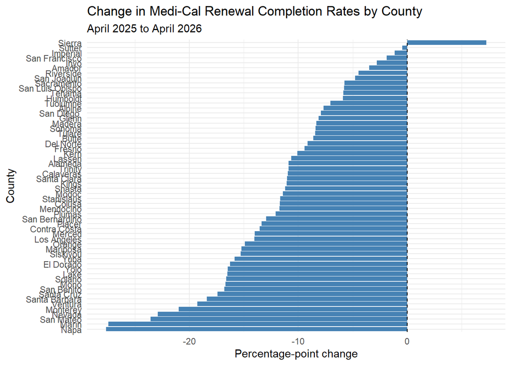

```r
 # Calculate: RENEWALS COMPLETED BY DUE DATE / RENEWALS DUE for april 25 and april 26 and percent change between these ratios

renewals_april_wide%>%
   mutate(
    renewal_rate_2025_04 = renewals_completed_by_due_date_2025_04 / renewals_due_2025_04 * 100,

    renewal_rate_2026_04 =renewals_completed_by_due_date_2026_04 / renewals_due_2026_04 * 100,

    renewal_rate_pp_change = renewal_rate_2026_04 - renewal_rate_2025_04
  )%>%
  select(county, renewal_rate_2025_04,  renewal_rate_2026_04,  renewal_rate_pp_change)%>%
  ggplot(aes(x = reorder(county, renewal_rate_pp_change),
             y = renewal_rate_pp_change)) +
  geom_col(fill = "steelblue") +
  coord_flip() +
  geom_hline(yintercept = 0, linetype = "dashed") +
  labs(
    title = "Change in Medi-Cal Renewal Completion Rates by County",
    subtitle = "April 2025 to April 2026",
    x = "County",
    y = "Percentage-point change"
  ) +
  theme_minimal()
```

# RENEWALS COMPLETED / RENEWALS DUE for april 2025 and april 2026 and percent change between these ratios (MAGI + NON MAGI)

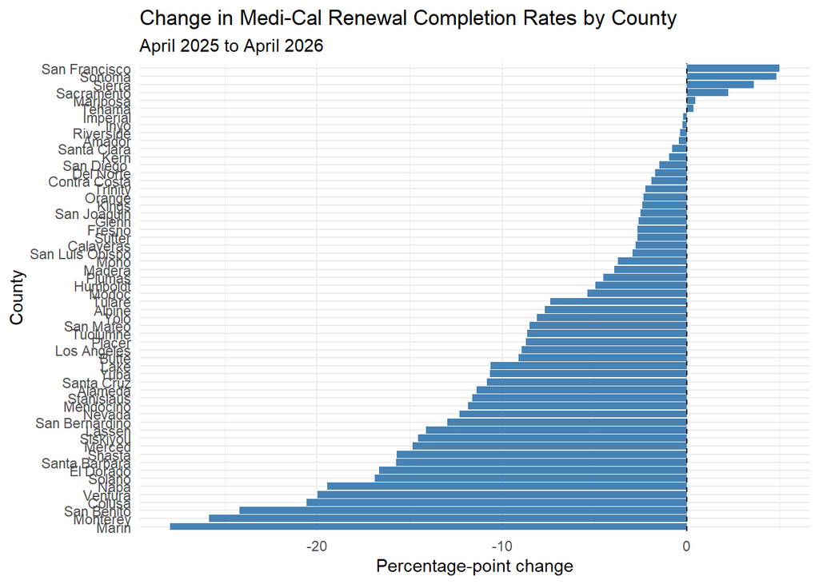

```r
 # Calculate: RENEWALS COMPLETED BY DUE DATE / RENEWALS DUE for april 25 and april 26 and percent change between these ratios

renewals_april_wide%>%
   mutate(
    renewal_rate_2025_04 = renewals_completed_2025_04 / renewals_due_2025_04 * 100,

    renewal_rate_2026_04 =renewals_completed_2026_04 / renewals_due_2026_04 * 100,

    renewal_rate_pp_change = renewal_rate_2026_04 - renewal_rate_2025_04
  )%>%
  select(county, renewal_rate_2025_04,  renewal_rate_2026_04,  renewal_rate_pp_change)%>%
  ggplot(aes(x = reorder(county, renewal_rate_pp_change),
             y = renewal_rate_pp_change)) +
  geom_col(fill = "steelblue") +
  coord_flip() +
  geom_hline(yintercept = 0, linetype = "dashed") +
  labs(
    title = "Change in Medi-Cal Renewal Completion Rates by County",
    subtitle = "April 2025 to April 2026",
    x = "County",
    y = "Percentage-point change"
  ) +
  theme_minimal()
```